# CS6313.002 Statistical Project 1

Ruolan Zeng(rxz171630), Vineet Vilas Amonkar(vva180000), Aakash Kamlesh Punjabi( akp170430)

October 24, 2018

## Alternate method

Loading the token data:

```r
tokenData <- read.delim("networkstorjTX.txt", header = FALSE, sep = " ")
tokenFrame<- as.data.frame(tokenData)
colnames(tokenFrame)<-c('fromNode','toNode','unixTime','totalAmount')
head(tokenFrame)
```

```
##   fromNode  toNode   unixTime  totalAmount
## 1  6103619 5607448 1524611290 230769000000
## 2       17  930403 1524611565  98700000000
## 3   930403       5 1524612137  98700000000
## 4   148332 1757147 1524612282  80312639339
## 5       17     573 1524612421 212877929273
## 6      573       5 1524612737 212877929273
```

Removing Outliers from the token data:

```r
TotalSupply <- 424999998
Decimals <- 10^8
OutlierValue <- TotalSupply*Decimals
WithoutOutlierdata <- tokenFrame[ which(tokenFrame$totalAmount < OutlierValue),]
head(WithoutOutlierdata)
```

```
##   fromNode  toNode   unixTime  totalAmount
## 1  6103619 5607448 1524611290 230769000000
## 2       17  930403 1524611565  98700000000
## 3   930403       5 1524612137  98700000000
## 4   148332 1757147 1524612282  80312639339
## 5       17     573 1524612421 212877929273
## 6      573       5 1524612737 212877929273
```

Summary of the token data without outlier:

```r
summary(WithoutOutlierdata$totalAmount)
```

```
##      Min.   1st Qu.    Median      Mean   3rd Qu.      Max.
## 1.000e+00 1.203e+08 1.742e+08 2.710e+11 3.159e+09 2.450e+16
```

Max amount of the token data without outlier:

```r
max(WithoutOutlierdata$totalAmount)
```

```
## [1] 2.45e+16
```

First step: Ensure that the Storj token data is within the time frame of the Price Data

Following is the date interval of the price data:

Start Date: 07/02/2017 End Date: 07/15/2018

Lets check the date range for the token data

First convert the Unix time of the token data to Date format

```r
newwithoutoutlierdata <- WithoutOutlierdata
newwithoutoutlierdata$unixTime <- as.Date(as.POSIXct(WithoutOutlierdata$unixTime,origin="1970-01-01",tz="GMT"))
```

Find the start and end date of the token data:

```r
max(newwithoutoutlierdata$unixTime)
```

```
## [1] "2018-05-06"
```

```r
min(newwithoutoutlierdata$unixTime)
```

```
## [1] "2017-06-19"
```

Subset the token data to match the dates of the pricedata:

```r
newwithoutoutlierdata <- subset(newwithoutoutlierdata, unixTime >=as.Date("2017-07-02"))
```

Second step:

Plot the graph of frequency of transaction amounts of the token data to decide splitting of the layers

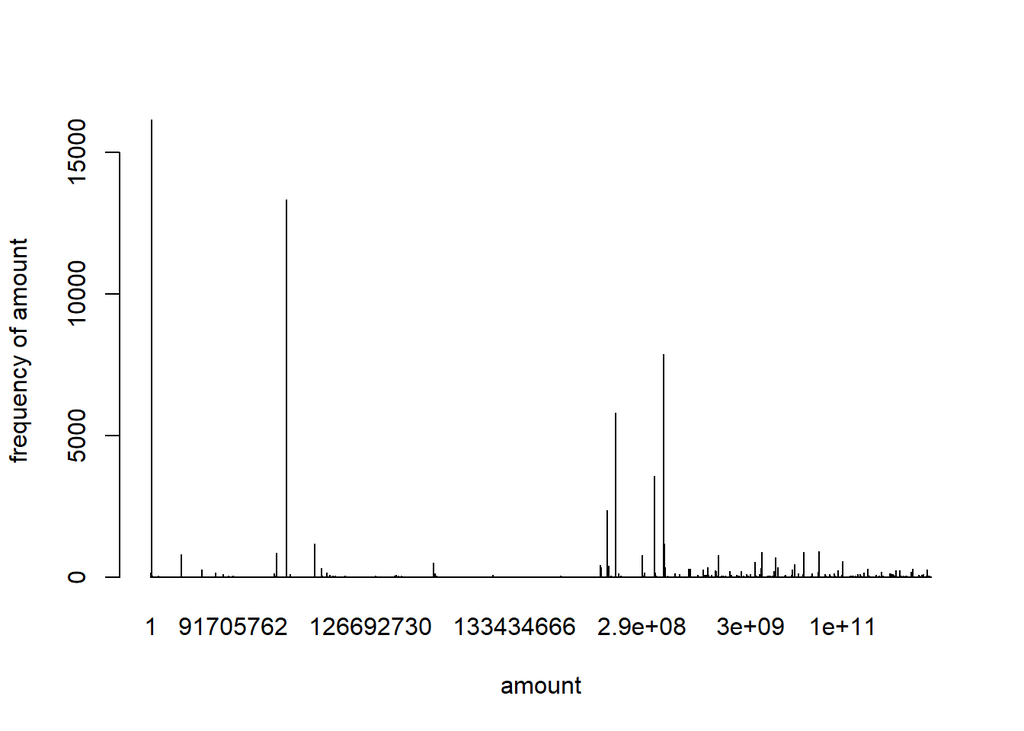

```r
amountfreqtable <- table(newwithoutoutlierdata$totalAmount)
amountfreqdf <- as.data.frame(amountfreqtable)
colnames(amountfreqdf) <- c("amount","amountfrequency")
barplot(amountfreqdf$amountfrequency,names.arg = amountfreqdf$amount, ylab = "frequency of amount", xlab="amount")
```

Third step:

Dividing the layers as per the above graph:

Since there are 379 rows in the price data we will use 379 layers but just for accounting any missed outliers we will create 388 layers

further we divide the layers in 3 sections:

First layer section:

```r
difflayer1 <- 1e+8 - min(newwithoutoutlierdata$totalAmount)

dividelayer1 <- difflayer1/130
alpha <- array()
layer <- list()
alpha[1] = c(min(newwithoutoutlierdata$totalAmount)+dividelayer1)
layer[[1]] <- newwithoutoutlierdata[ which(newwithoutoutlierdata$totalAmount < alpha[1]),]
for(j in 2:130){
  alpha[j] <- min(newwithoutoutlierdata$totalAmount)+(j)*dividelayer1
  layer[[j]] <- newwithoutoutlierdata[ which( newwithoutoutlierdata$totalAmount < alpha[j] & newwithoutoutlierdata$totalAmount >= alpha[j-1]),]
}
```

The Second section has 248 layers contains value between $1\times10^8$ and $6.4\times10^{13}$ also we have divided the layers with interval of $0.3\times10^8$

```r
dividelayer2 <- 0.3e+8
for(j in 1:247){
  # print(j)
  alpha[130+j] <- max(layer[[130]]$totalAmount)+(j)*dividelayer2
  # print(alpha)
  #value[j] <- alpha*max(WithoutOutlierdata$totalAmount)
  layer[[130+j]] <- newwithoutoutlierdata[ which( newwithoutoutlierdata$totalAmount < alpha[130+j] & newwithoutoutlierdata$totalAmount >= alpha[129+j]),]
  #NumberOfTrans1[j] <- (length(layer[j]))
}
alpha[378] <- 6.4e+13
layer[[378]] <- newwithoutoutlierdata[ which( newwithoutoutlierdata$totalAmount < alpha[378] & newwithoutoutlierdata$totalAmount >= alpha[377]),]
```

The Third Section contains 10 layers of all the amounts greater than $6.4\times10^{13}$

```r
temp1<-max(layer[[378]]$totalAmount)
temp2<-max(newwithoutoutlierdata$totalAmount)
difflayer3 <- temp2 - temp1

dividelayer3 <- difflayer3/10


for(j in 1:10){

  alpha[378+j] <- max(layer[[378]]$totalAmount)+(j)*dividelayer3


  layer[[378+j]] <- newwithoutoutlierdata[ which( newwithoutoutlierdata$totalAmount <= alpha[378+j] & newwithoutoutlierdata$totalAmount >= alpha[377+j]),]

}
```

Fourth step: check the number of transactions in each layer

```r
sapply(layer,nrow)
```

```
##   [1]   127    32     6     4     2     9    10    10     4     4    11
##  [12]    19   155     4     4     8     3     3     4     8     4     3
##  [23]     0     6     1    36     2     2     6     2     0     3     2
##  [34]     6     4     5     5     4    10     3     3     5     5     4
##  [45]     1     1     1     1     4     3     4     9     0     3     2
##  [56]     2     2     4     7     2     4     1     5     7    65     3
##  [67]     1     6     3     2     2     4     2     3     3     1     7
##  [78]    15     1     0     6     5     0     2     2     5     7     0
##  [89]     5     1     8     2     0     4     0     0     6     1     2
## [100]     1     2     1     1     8     2     2     1     2     4     6
## [111]     7     3     0     0     2     7     9 27917 20396  5939  3428
## [122]  2406  1728  1459  1181  1046   882   796   829   605 83402 45998
## [133] 10310  5290 14669  3787  3566  1973  7391 24387  2738  1452  1466
## [144]  1378   832   730   720   576   596   607   882   647  3247   511
## [155]   335   385   624   539   386   499  1114   297   258   369   289
```

[output cut: 21 more lines]

Fifth step:

Observations: The layers from 380 to 388 do not have much significant no of transactions hence we will ignore them while calculating correlation

Finding correlation of no of transactions of each layer with the price data:

```r
NumberOfTrans <- sapply(layer,nrow)
priceData <- read.delim("storj", header = TRUE, sep = "\t")
cor(priceData$Close, NumberOfTrans[1:379],use="complete.obs",method = "pearson")
```

```
## [1] 0.02425848
```

```r
cor(priceData$Open, NumberOfTrans[1:379],use="complete.obs",method = "pearson")
```

```
## [1] 0.01007584
```

```r
cor(priceData$High, NumberOfTrans[1:379],use="complete.obs",method = "pearson")
```

```
## [1] 0.02255076
```

```r
cor(priceData$Low, NumberOfTrans[1:379],use="complete.obs",method = "pearson")
```

```
## [1] 0.007656099
```

Result:

The calculated correlation result can be improved further by modifying the layer intervals as it can be seen from each layer data that it is not uniformly divided.

Thank You